# Projekt 1, SAD 2022. Analiza danych ‘people’.

Krzysztof Zdąbłasz

# ZAD. 1

## 1.1 Eksploracja danych

```r
dane = read.table("people.tab.csv", header = TRUE, stringsAsFactors = TRUE)
summary(dane)
```

```
##       wiek            waga            wzrost        plec     stan_cywilny
##  Min.   :17.00   Min.   : 45.20   Min.   :113.6   K   :239   Mode :logical
##  1st Qu.:33.00   1st Qu.: 59.20   1st Qu.:155.6   M   :223   FALSE:327
##  Median :39.00   Median : 67.50   Median :169.0   NA's: 38   TRUE :173
##  Mean   :39.48   Mean   : 68.03   Mean   :168.2
##  3rd Qu.:45.00   3rd Qu.: 75.60   3rd Qu.:180.1
##  Max.   :72.00   Max.   :107.20   Max.   :235.2
##  liczba_dzieci            budynek       wydatki        oszczednosci
##  Min.   :0.000   apartament   : 54   Min.   : 524.9   Min.   :-685.68
##  1st Qu.:0.750   jednorodzinny:187   1st Qu.:1807.0   1st Qu.:  74.52
##  Median :1.000   kamienica    :105   Median :2489.9   Median : 402.22
##  Mean   :1.558   loft         : 54   Mean   :2511.7   Mean   : 478.60
##  3rd Qu.:2.000   wielka_plyta :100   3rd Qu.:3084.5   3rd Qu.: 802.73
##  Max.   :6.000                       Max.   :5574.6   Max.   :3503.90
```

**W danych znajduje się 500 obserwacji. Jest to łącznie 9 zmiennych.**

- 6 zmiennych ilościowych:
  - Wiek
  - Waga
  - Wzrost
  - Liczba dzieci
  - Wydatki
  - Oszczędności
- 3 zmienne jakościowe:
  - Płeć
  - Stan cywilny
  - Budynek

**Ogólnie dane są poprawne i pełne, natomiast w kolumnie płeć 38 danych jest niedostępne (NA).**

```r
print( paste('Puste obserwacje: ',sum(is.na(dane))) )
```

```
## [1] "Puste obserwacje:  38"
```

**Potwierdzenie, że tylko te dane są niedostępne.**

## 1.2 Zależności między zmiennymi ilościowymi

**W celu zbadania zależności między zmiennymi ilościowymi obliczam współczynniki korelacji Pearsona**

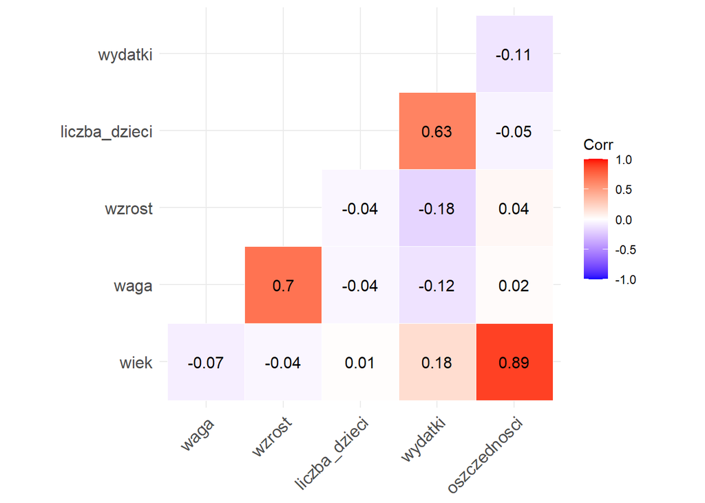

```r
zmienne_ilosciowe = c(1,2,3,6,8,9)
zmienne_jakosciowe = c(4,5,7)

corelation = cor(dane[zmienne_ilosciowe], method='pearson')
ggcorrplot(corelation, type="lower", lab=TRUE, outline.color = "white")
```

**Okazuje się, że w danych występuje silna liniowa korelacja między zmiennymi *oszczędności* a *wiek* (współczynnik korelacji równy ~0.89). Zauważalna jest również korelacja między wzrostem a wagą (~0.7) oraz słabsza między liczbą dzieci a wydatkami (~0.63).**

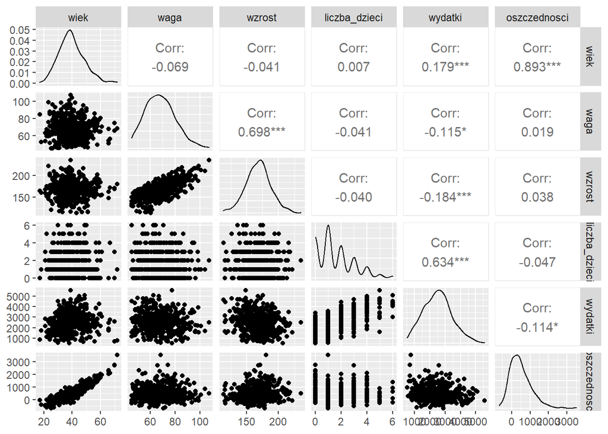

```r
ggpairs(dane[zmienne_ilosciowe])
```

```r
rcorr(as.matrix(dane[zmienne_ilosciowe]))$P
```

```
##                       wiek       waga       wzrost liczba_dzieci      wydatki
## wiek                    NA 0.12237100 3.567464e-01     0.8774972 5.753351e-05
## waga          1.223710e-01         NA 0.000000e+00     0.3649992 1.001404e-02
## wzrost        3.567464e-01 0.00000000           NA     0.3724688 3.645197e-05
## liczba_dzieci 8.774972e-01 0.36499919 3.724688e-01            NA 0.000000e+00
## wydatki       5.753351e-05 0.01001404 3.645197e-05     0.0000000           NA
## oszczednosci  0.000000e+00 0.67419281 3.960759e-01     0.2968250 1.101304e-02
##               oszczednosci
## wiek            0.00000000
## waga            0.67419281
## wzrost          0.39607587
## liczba_dzieci   0.29682500
## wydatki         0.01101304
## oszczednosci            NA
```

**Macierz p-wartości dla statystyki, w której hipotezą zerową jest założenie o nieskorelowaniu zmiennych. Dla przecięć oszczędności-wiek, waga-wzrost oraz liczba_dzieci-wydatki p-wartości są praktycznie równe zeru. Daje to podstawy do odrzucenia hipotezy zerowej dla tych par.**

## 1.3 Zależności między zmiennymi jakościowymi

**W celu zbadania zależności między zmiennymi jakościowymi wykonam testy chi-kwadrat. Na wszelki wypadek testy zostaną przeprowadzone rówież dla danych po usunięciu rekordów zawierających NA.**

```r
dane_bezNA = na.omit(dane)

chisq.test(dane_bezNA[zmienne_jakosciowe]$plec,dane_bezNA[zmienne_jakosciowe]$stan_cywilny)
```

```
##
##  Pearson's Chi-squared test with Yates' continuity correction
##
## data:  dane_bezNA[zmienne_jakosciowe]$plec and dane_bezNA[zmienne_jakosciowe]$stan_cywilny
## X-squared = 2.2877, df = 1, p-value = 0.1304
```

```r
chisq.test(dane_bezNA[zmienne_jakosciowe]$plec,dane_bezNA[zmienne_jakosciowe]$budynek)
```

```
##
##  Pearson's Chi-squared test
##
## data:  dane_bezNA[zmienne_jakosciowe]$plec and dane_bezNA[zmienne_jakosciowe]$budynek
## X-squared = 1.4097, df = 4, p-value = 0.8425
```

```r
chisq.test(dane_bezNA[zmienne_jakosciowe]$stan_cywilny,dane_bezNA[zmienne_jakosciowe]$budynek)
```

```
##
##  Pearson's Chi-squared test
##
## data:  dane_bezNA[zmienne_jakosciowe]$stan_cywilny and dane_bezNA[zmienne_jakosciowe]$budynek
## X-squared = 4.8745, df = 4, p-value = 0.3004
```

```r
# ----------------------------------------------------------------------------------------------
chisq.test(dane[zmienne_jakosciowe]$plec,dane[zmienne_jakosciowe]$stan_cywilny)
```

```
##
##  Pearson's Chi-squared test with Yates' continuity correction
##
## data:  dane[zmienne_jakosciowe]$plec and dane[zmienne_jakosciowe]$stan_cywilny
## X-squared = 2.2877, df = 1, p-value = 0.1304
```

```r
chisq.test(dane[zmienne_jakosciowe]$plec,dane[zmienne_jakosciowe]$budynek)
```

```
##
##  Pearson's Chi-squared test
##
## data:  dane[zmienne_jakosciowe]$plec and dane[zmienne_jakosciowe]$budynek
## X-squared = 1.4097, df = 4, p-value = 0.8425
```

```r
chisq.test(dane[zmienne_jakosciowe]$stan_cywilny,dane[zmienne_jakosciowe]$budynek)
```

```
##
##  Pearson's Chi-squared test
##
## data:  dane[zmienne_jakosciowe]$stan_cywilny and dane[zmienne_jakosciowe]$budynek
## X-squared = 5.807, df = 4, p-value = 0.214
```

**Wyniki testów są zdecydowanie wyższe niż 0.05, więc nie ma podstaw do odrzucenia hipotezy zerowej o niezależności żadnej z badanych par zmiennych jakościowych.**  
**Dodatkowe ilustracje:**

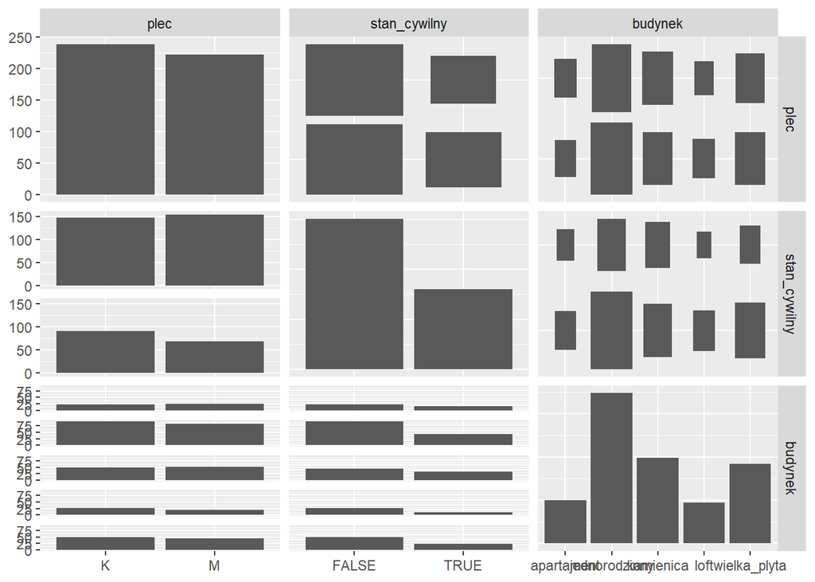

```r
ggpairs(dane_bezNA[zmienne_jakosciowe])
```

# ZAD. 2

## 2.1 Wykres typu scatter-plot

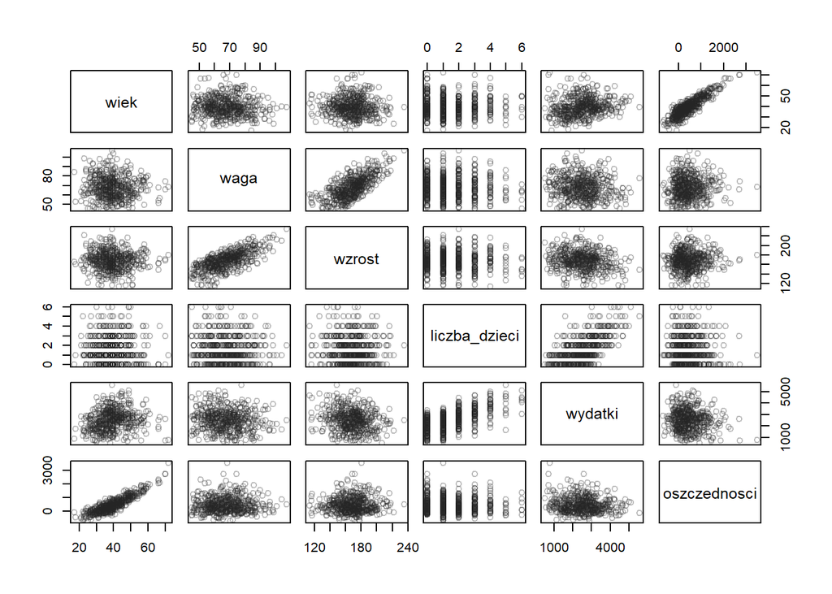

```r
pairs(dane[zmienne_ilosciowe], col='#2424244d')
```

## 2.2 Wykres typu box-plot

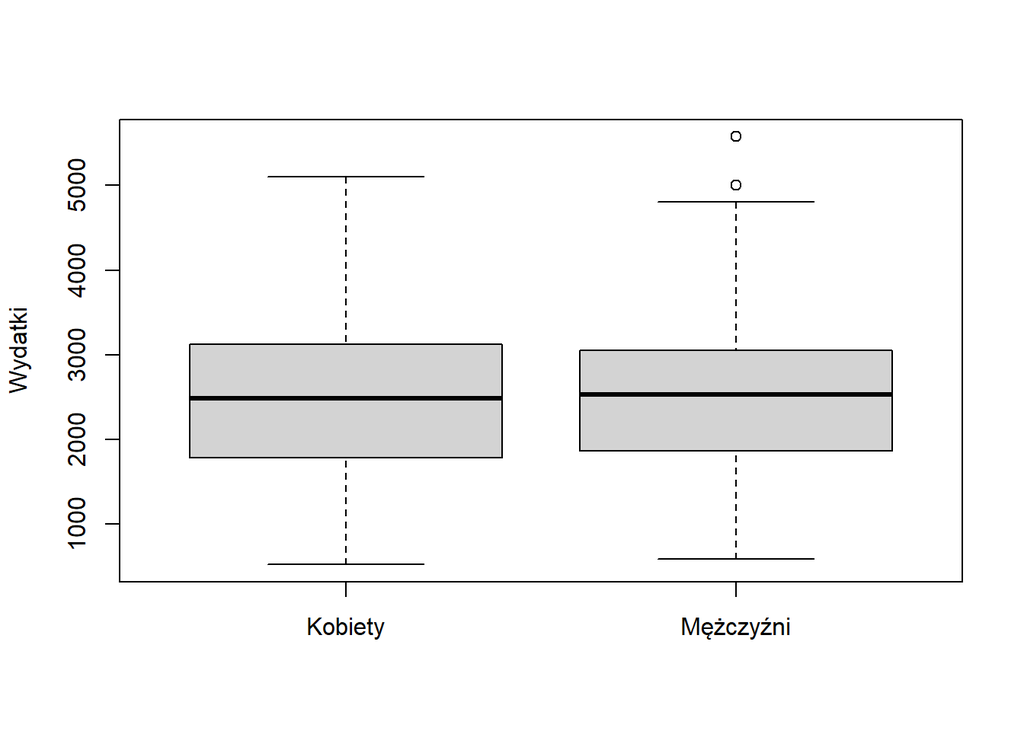

```r
kobiety = subset(dane, plec == 'K')
mezczyzni = subset(dane, plec == 'M')
boxplot(kobiety$wydatki,mezczyzni$wydatki, ylab='Wydatki',names=c('Kobiety','Mężczyźni'))
```

## 2.3 Wykres typu pie-chart

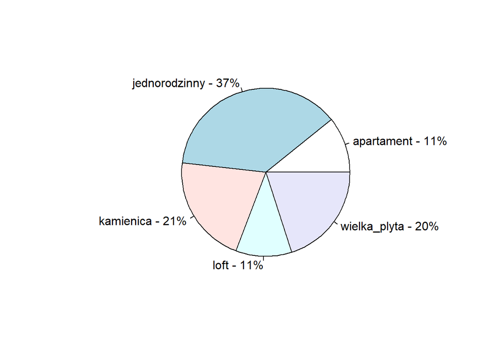

```r
tabela = table(dane$budynek)
percents = round(as.numeric(tabela)/sum(tabela)*100)
percents = paste(percents,'%',sep='')
names = names(tabela)
labels = paste(names,'-',percents,sep=' ')

pie(tabela, labels = labels)
```

# ZAD. 3

**Do sprawdzenia p-wartości dla hipotezy o wartości średniej = 170[cm] wykorzystam test t-studenta, ponieważ nie znamy wartośći średniej ani wariancji. Test ten wymaga założenia, że dane mają rozkład normalny. Warto jest sprawdzić to założenie, chociaż tak naprawdę są to dane dotyczące wzrostu, a cecha ta ma w społczeństwie rozkład normalny, ponadto danych jest dużo (500).**

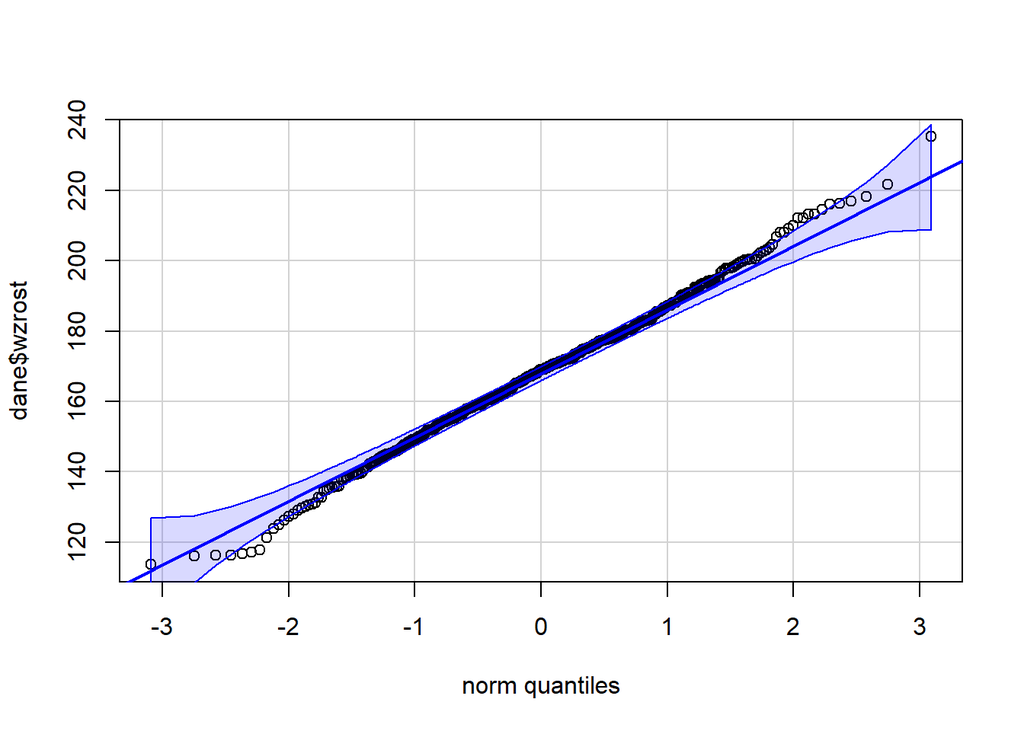

```r
qqPlot(dane$wzrost,id=FALSE)
```

**Zdecydowana większość danych zawiera się w przedziale narysowanym przez funkcję qqPlot. Kilka z nich wypada z przedziału (na początku i końcu), ale nie powinny mieć one dużego wpływu.**

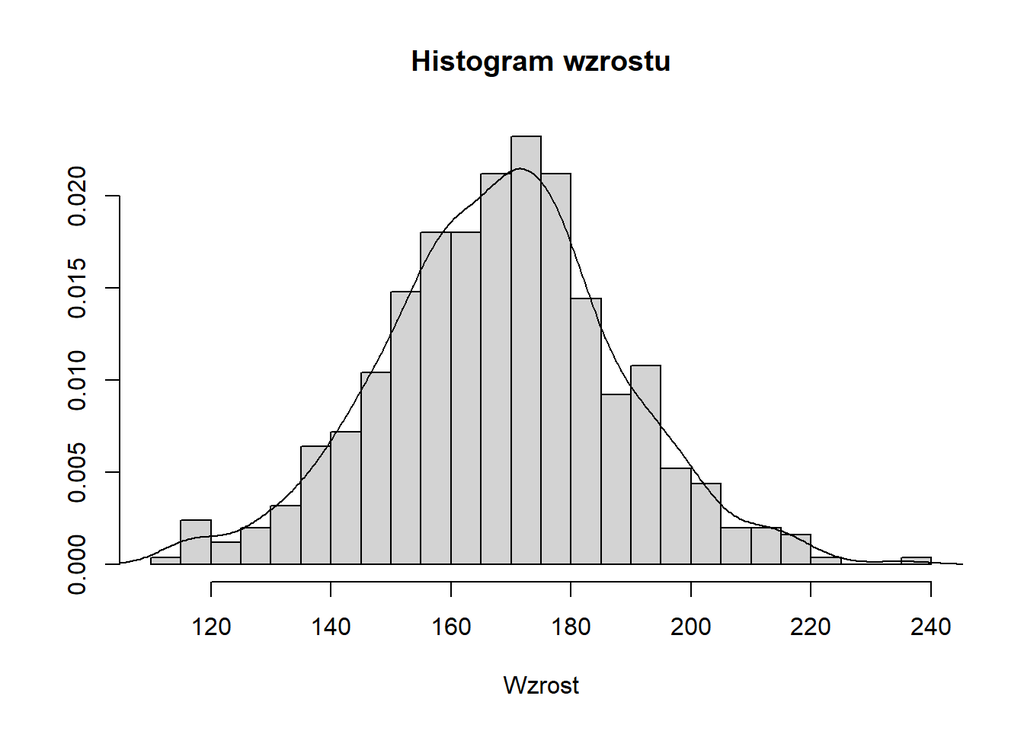

```r
hist(dane$wzrost, prob=TRUE,main='Histogram wzrostu',breaks=25,ylab = '',xlab='Wzrost')
lines(density(dane$wzrost))
```

**Histogram ukazuje gęstość bardzo zbliżoną do rozkładu normalnego. Niemniej jednak można przeprowadzić dodatkowy test Shapiro-Wilka.**

```r
shapiro.test(dane$wzrost)
```

```
##
##  Shapiro-Wilk normality test
##
## data:  dane$wzrost
## W = 0.99662, p-value = 0.3778
```

**Wynik nie daje podstaw do odrzucenia hipotezy zerowej, że wzrost ma rozkład normalny - p-wartość jest wysoka. Można więc przejść do wyznaczenia p-wartości hipotez z treści zadania.**

```r
pval170 = t.test(dane$wzrost, mu = 170, alternative = "less")$p.value
print(paste('p-value dla hipotezy o średniej = 170[cm]: ',pval170,sep=' '))
```

```
## [1] "p-value dla hipotezy o średniej = 170[cm]:  0.0194870185113313"
```

**Brak podstaw do odrzucenia hipotezy zerowej.**  
**Do sprawdzenia p-wartości dla hipotezy o medianie równej 165[cm] wykorzystam test Wilcoxona.**

```r
pval165 = wilcox.test(dane$wzrost, mu=165, alternative="less")$p.value
print(paste('p-value dla hipotezy o medianie = 165[cm]: ',pval165,sep=' '))
```

```
## [1] "p-value dla hipotezy o medianie = 165[cm]:  0.999867771575833"
```

**Bardzo wysoka p-value (prawie równa 1), brak podstaw do odrzucenia hipotezy zerowej.**

# ZAD. 4

```r
n=nrow(dane)
srednia=mean(dane$wiek)
sdt=sd(dane$wiek)
alfa=0.01
kwantyl=qnorm(1-alfa/2)
```

**Przedział ufności dla średniej**

```r
c(srednia - kwantyl*sdt/sqrt(n), srednia + kwantyl*sdt/sqrt(n))
```

```
## [1] 38.44997 40.51803
```

**Przedział ufności dla odchylenia standardowego**

```r
sdt*sqrt(2*n) / c(sqrt(2*n-3)+kwantyl, sqrt(2*n-3)-kwantyl)
```

```
## [1] 8.311793 9.788355
```

**Przedział ufności dla kwantyli**

```r
quantileCI(dane$wiek, prob = 0.25, conf.level = 0.99)
```

```
##      lower upper
## 0.25    32    35
```

```r
quantileCI(dane$wiek, prob = 0.5, conf.level = 0.99)
```

```
##     lower upper
## 0.5    38    40
```

```r
quantileCI(dane$wiek, prob = 0.75, conf.level = 0.99)
```

```
##      lower upper
## 0.75    43    47
```

# ZAD 5.

## 5.1 Średnie wybranej zmiennej między osobami po ślubie a bez ślubu są równe

**Zmienna wzrost. Wykorzystam test t-studenta dla dwóch próbek. Zakładam, że mają rozkład normalny, bo zmienna wzrost ma rozkład normalny co sprawdziliśmy wcześniej. Można to też zobaczyć korzystając z qqPlot, prawie wszystkie obserwacje wpadają w obszar, ale nie będę ich już tutaj umieszczał. H0 - średnie są takie same.**

```r
po_slubie = dane[dane$stan_cywilny == TRUE,]
bez_slubu = dane[dane$stan_cywilny == FALSE,]
t.test(po_slubie$wzrost, bez_slubu$wzrost, conf.level = 0.99)
```

```
##
##  Welch Two Sample t-test
##
## data:  po_slubie$wzrost and bez_slubu$wzrost
## t = -0.43197, df = 302.94, p-value = 0.6661
## alternative hypothesis: true difference in means is not equal to 0
## 99 percent confidence interval:
##  -5.893857  4.210092
## sample estimates:
## mean of x mean of y
##  167.6298  168.4717
```

**Wynik testu świadczy o tym, że nie ma podstaw do odrzucenia hipotezy zerowej.**

## 5.2 Dwie wybrane zmienne ilościowe są niezależne

**Zmienne wiek i liczba_dzieci. Do zbadania niezależności zmiennych ilościowych wykorzystam test korelacji z H0, że cor=0.**

```r
cor.test(dane$wiek, dane$liczba_dzieci, conf.level = 0.99)
```

```
##
##  Pearson's product-moment correlation
##
## data:  dane$wiek and dane$liczba_dzieci
## t = 0.15422, df = 498, p-value = 0.8775
## alternative hypothesis: true correlation is not equal to 0
## 99 percent confidence interval:
##  -0.1082056  0.1218441
## sample estimates:
##         cor
## 0.006910684
```

**Nie są skorelowane.**

## 5.3 Dwie wybrane zmienne jakościowe są niezależne

**Założenie, że wartości są skokowe spełniona. H0 - płeć i stan cywilny są niezależne.**

```r
chisq.test(table(dane[c(4,5)]))
```

```
##
##  Pearson's Chi-squared test with Yates' continuity correction
##
## data:  table(dane[c(4, 5)])
## X-squared = 2.2877, df = 1, p-value = 0.1304
```

**p-value jest większe niż przedział ufności 0.01. Nie ma podstaw do odrzucenia hipotezy zerowej.**

## 5.4 Zgodność z rozkładem parametrycznym

**Sprawdzenie czy rozkład wzrostu jest zgodny z rozkładem wykładniczym z parametrem 5. H0 - jest zgodny. Test Kołomogorowa-Smirnowa.**

```r
set.seed(420) # ustalenie liczb losowych dla reprodukowalności - wygenerowane dane z rozkładu wykładniczego
ks.test(dane$wzrost,rexp(500, rate=5))
```

```
##
##  Asymptotic two-sample Kolmogorov-Smirnov test
##
## data:  dane$wzrost and rexp(500, rate = 5)
## D = 1, p-value < 2.2e-16
## alternative hypothesis: two-sided
```

**p-wartość bardzo niska, niższa niż 0.01. Odrzucamy hipotezę zerową (zresztą wcześniej sprawdziliśmy, że wzrost ma rozkład normalny, więc wydaje się to oczywiste.**

# ZAD. 6

**Zacznijmy od pełnego modelu (dane bez obserwacji zawierających NA)**

```r
pelny_model = lm(formula = oszczednosci ~ wiek + waga + wzrost + plec + stan_cywilny +  liczba_dzieci + budynek + wydatki, data = dane_bezNA)
summary(pelny_model)
```

```
##
## Call:
## lm(formula = oszczednosci ~ wiek + waga + wzrost + plec + stan_cywilny +
##     liczba_dzieci + budynek + wydatki, data = dane_bezNA)
##
## Residuals:
##     Min      1Q  Median      3Q     Max
## -307.64  -60.13   -1.69   58.06  462.98
##
## Coefficients:
##                        Estimate Std. Error t value Pr(>|t|)
## (Intercept)          -873.59106   58.76098 -14.867  < 2e-16 ***
## wiek                   63.94258    0.56712 112.750  < 2e-16 ***
## waga                    3.94409    0.56935   6.927 1.49e-11 ***
## wzrost                 -2.38464    0.35204  -6.774 3.94e-11 ***
## plecM                   1.38069    9.63179   0.143    0.886
## stan_cywilnyTRUE       -4.61252   12.91187  -0.357    0.721
## liczba_dzieci         151.60355    6.15687  24.623  < 2e-16 ***
## budynekjednorodzinny -182.07031   16.43991 -11.075  < 2e-16 ***
## budynekkamienica     -305.63144   17.89020 -17.084  < 2e-16 ***
## budynekloft          -338.47001   25.14078 -13.463  < 2e-16 ***
## budynekwielka_plyta  -564.26015   20.59225 -27.402  < 2e-16 ***
## wydatki                -0.39593    0.01057 -37.455  < 2e-16 ***
## ---
## Signif. codes:  0 '***' 0.001 '**' 0.01 '*' 0.05 '.' 0.1 ' ' 1
##
## Residual standard error: 102 on 450 degrees of freedom
## Multiple R-squared:  0.9673, Adjusted R-squared:  0.9665
## F-statistic:  1209 on 11 and 450 DF,  p-value: < 2.2e-16
```

```r
summary(pelny_model)$coefficients[,4] # p-wartości zmiennych w pełnym modelu
```

```
##          (Intercept)                 wiek                 waga
##         5.903953e-41         0.000000e+00         1.490112e-11
##               wzrost                plecM     stan_cywilnyTRUE
##         3.937286e-11         8.860806e-01         7.210861e-01
##        liczba_dzieci budynekjednorodzinny     budynekkamienica
##         2.061387e-85         2.256391e-25         8.459593e-51
##          budynekloft  budynekwielka_plyta              wydatki
##         5.900373e-35         5.816251e-98        2.193560e-140
```

```r
pelny_model_rss = sum(pelny_model$residuals^2)
pelny_model_r2 = summary(pelny_model)$r.squared
```

**Ogólnie poza płcią i stanem cywilnym, wszystkie zmienne wydają się być ważne dla naszego modelu. Mają bardzo niskie p-wartości.**

**Stworzenie modeli z różnymi pominiętymi zmiennymi i porównanie do głównego modelu:**

```r
models = list(
  pelny_model,
  lm(formula = oszczednosci ~ wiek + waga + wzrost + plec + stan_cywilny +  liczba_dzieci + budynek, data = dane_bezNA),
  lm(formula = oszczednosci ~ wiek + waga + wzrost + plec + stan_cywilny +  liczba_dzieci + wydatki, data = dane_bezNA),
  lm(formula = oszczednosci ~ wiek + waga + wzrost + plec + stan_cywilny + budynek + wydatki, data = dane_bezNA),
  lm(formula = oszczednosci ~ wiek + waga + wzrost + plec +  liczba_dzieci + budynek + wydatki, data = dane_bezNA),
  lm(formula = oszczednosci ~ wiek + waga + wzrost + stan_cywilny +  liczba_dzieci + budynek + wydatki, data = dane_bezNA),
  lm(formula = oszczednosci ~ wiek + waga + plec + stan_cywilny +  liczba_dzieci + budynek + wydatki, data = dane_bezNA),
  lm(formula = oszczednosci ~ wiek + wzrost + plec + stan_cywilny +  liczba_dzieci + budynek + wydatki, data = dane_bezNA),
  lm(formula = oszczednosci ~ waga + wzrost + plec + stan_cywilny +  liczba_dzieci + budynek + wydatki, data = dane_bezNA)
)
names = c(
  'Pełny model','Bez wydatków','Bez budynku','Bez liczby dzieci','Bez stanu cywilnego','Bez płci','Bez wzrostu', 'Bez wagi','Bez wieku'

)
print_model_data <- function(specified_model, name,full_model_rss,full_model_r2){
  rss = sum(specified_model$residuals^2)
  r2 = summary(specified_model)$r.squared
  cat(paste(
    paste('Model:',name),
    paste('RSS: ',round(rss,digits=4),', R2: ',round(r2,digits=4), sep=''),
    paste('Wzrost RSS: ',round(rss-full_model_rss,digits=1),', Spadek R2: ',round(full_model_r2-r2,digits=8), sep='')
  ,'\n',sep='\n'))

}

i=1
for (m in models){
  print_model_data(m,names[i],pelny_model_rss,pelny_model_r2)
  i=i+1
}
```

```
## Model: Pełny model
## RSS: 4681333.857, R2: 0.9673
## Wzrost RSS: 0, Spadek R2: 0
##
## Model: Bez wydatków
## RSS: 19275685.2883, R2: 0.8652
## Wzrost RSS: 14594351.4, Spadek R2: 0.10206258
##
## Model: Bez budynku
## RSS: 13661075.9092, R2: 0.9045
## Wzrost RSS: 8979742.1, Spadek R2: 0.06279797
##
## Model: Bez liczby dzieci
## RSS: 10988813.821, R2: 0.9232
## Wzrost RSS: 6307480, Spadek R2: 0.04411006
##
## Model: Bez stanu cywilnego
## RSS: 4682661.4231, R2: 0.9673
## Wzrost RSS: 1327.6, Spadek R2: 9.28e-06
##
## Model: Bez płci
## RSS: 4681547.6199, R2: 0.9673
## Wzrost RSS: 213.8, Spadek R2: 1.49e-06
##
## Model: Bez wzrostu
## RSS: 5158667.9821, R2: 0.9639
## Wzrost RSS: 477334.1, Spadek R2: 0.00333814
##
## Model: Bez wagi
## RSS: 5180546.0236, R2: 0.9638
## Wzrost RSS: 499212.2, Spadek R2: 0.00349114
##
## Model: Bez wieku
## RSS: 136929242.0645, R2: 0.0424
## Wzrost RSS: 132247908.2, Spadek R2: 0.92484842
```

**Model bez płci i stanu cywilnego:**

```r
bez_dwoch = lm(formula = oszczednosci ~ wiek + waga + wzrost +  liczba_dzieci + budynek + wydatki, data = dane)
summary(bez_dwoch)
```

```
##
## Call:
## lm(formula = oszczednosci ~ wiek + waga + wzrost + liczba_dzieci +
##     budynek + wydatki, data = dane)
##
## Residuals:
##     Min      1Q  Median      3Q     Max
## -298.01  -63.22   -0.58   57.98  473.18
##
## Coefficients:
##                        Estimate Std. Error t value Pr(>|t|)
## (Intercept)          -8.487e+02  5.613e+01 -15.119  < 2e-16 ***
## wiek                  6.413e+01  5.383e-01 119.140  < 2e-16 ***
## waga                  3.633e+00  5.465e-01   6.649 7.91e-11 ***
## wzrost               -2.353e+00  3.420e-01  -6.882 1.81e-11 ***
## liczba_dzieci         1.539e+02  5.316e+00  28.945  < 2e-16 ***
## budynekjednorodzinny -1.850e+02  1.588e+01 -11.651  < 2e-16 ***
## budynekkamienica     -3.088e+02  1.731e+01 -17.847  < 2e-16 ***
## budynekloft          -3.490e+02  2.355e+01 -14.821  < 2e-16 ***
## budynekwielka_plyta  -5.720e+02  1.953e+01 -29.293  < 2e-16 ***
## wydatki              -4.021e-01  9.931e-03 -40.488  < 2e-16 ***
## ---
## Signif. codes:  0 '***' 0.001 '**' 0.01 '*' 0.05 '.' 0.1 ' ' 1
##
## Residual standard error: 102.5 on 490 degrees of freedom
## Multiple R-squared:  0.9679, Adjusted R-squared:  0.9673
## F-statistic:  1643 on 9 and 490 DF,  p-value: < 2.2e-16
```

```r
rss = sum(bez_dwoch$residuals^2)
r2 = summary(bez_dwoch)$r.squared
print(paste('RSS: ',rss,', R2: ',r2,sep=''))
```

```
## [1] "RSS: 5152668.42966533, R2: 0.967933481193267"
```

**Warto zauważyć, że R2 jest większe niż w początkowym modelu, co może wydawać się dziwne, ze względu na to, że pozbyliśmy się dwóch zmiennych. Użyliśmy natomiast danych powiększonych o 38 obserwacji, stąd ta różnica. Dodatkowa uwaga: wydaje mi się, że dzielenie danych na treningowe i testowe nie jest konieczne na potrzeby tego raportu, dlatego tego nie zrobiłem, chociaż normalnie bym zrobił (tak samo jak przekształcenie danych np na postać BMI, czy zastosowanie optymalizacji regresji).**

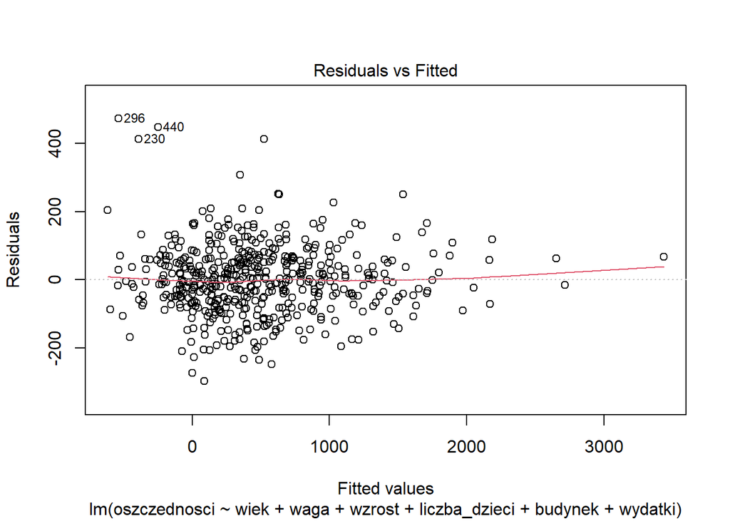

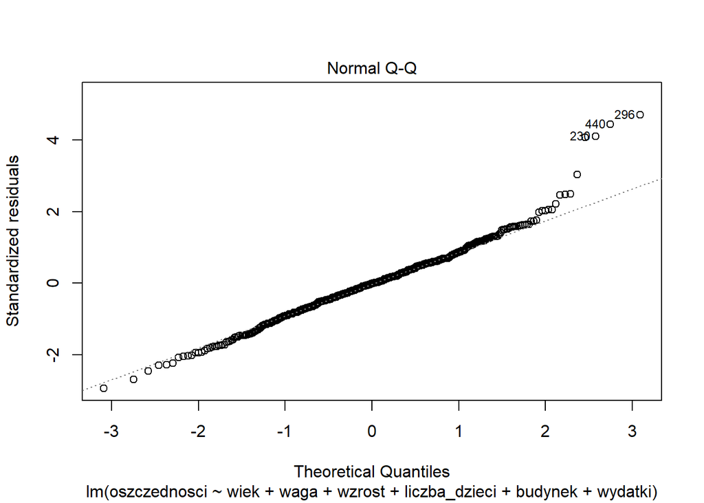

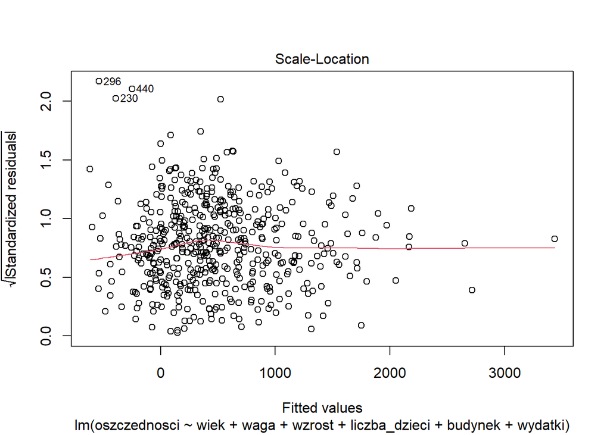

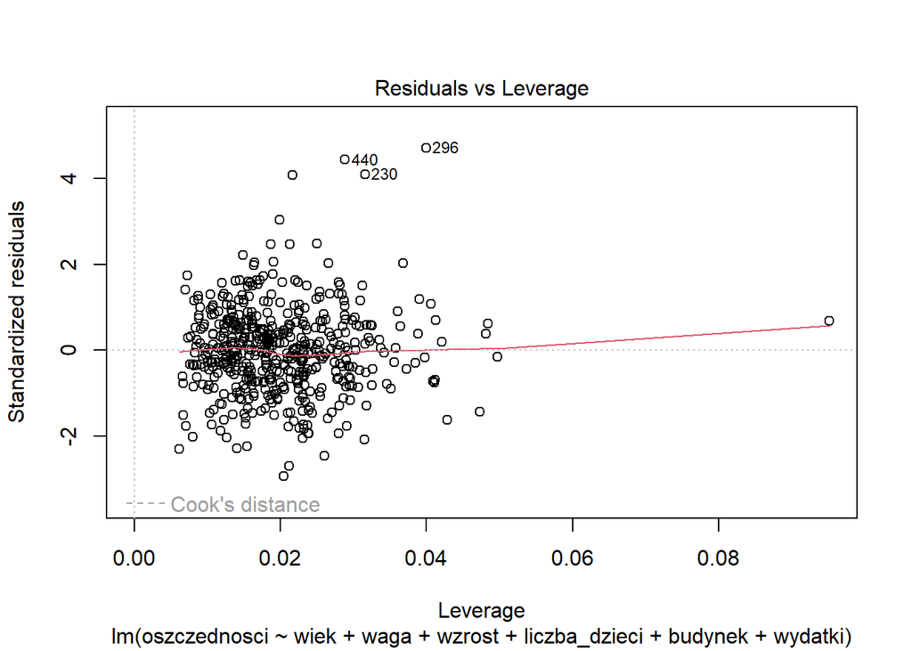

```r
plot(bez_dwoch)
```

**Jest kilka obserwacji odstających, których należałoby się pozbyć.**

```r
shapiro.test(bez_dwoch$residuals)
```

```
##
##  Shapiro-Wilk normality test
##
## data:  bez_dwoch$residuals
## W = 0.97407, p-value = 9.637e-08
```

**Test Shapiro-Wilka wskazuje na to, że założenie o rozkładzie normalnym nie jest spełnione. Po przeprowadzonych analizach wybrałem 5 obserwacji odstających (440,230,296,137,121) i pozbyłem się ich z końcowego modelu.**

```r
odstajace = c(440,230,296,137,121)
dane_bez_odstajacych = dane[-odstajace,]
model_poprawiony = lm(formula = oszczednosci ~ wiek + waga + wzrost +  liczba_dzieci + budynek + wydatki, data = dane_bez_odstajacych)
summary(model_poprawiony)
```

```
##
## Call:
## lm(formula = oszczednosci ~ wiek + waga + wzrost + liczba_dzieci +
##     budynek + wydatki, data = dane_bez_odstajacych)
##
## Residuals:
##      Min       1Q   Median       3Q      Max
## -285.635  -55.762    2.427   58.417  300.934
##
## Coefficients:
##                        Estimate Std. Error t value Pr(>|t|)
## (Intercept)          -8.465e+02  5.083e+01 -16.655  < 2e-16 ***
## wiek                  6.499e+01  4.943e-01 131.487  < 2e-16 ***
## waga                  3.488e+00  4.963e-01   7.029 7.11e-12 ***
## wzrost               -2.421e+00  3.103e-01  -7.803 3.73e-14 ***
## liczba_dzieci         1.596e+02  4.843e+00  32.951  < 2e-16 ***
## budynekjednorodzinny -1.851e+02  1.436e+01 -12.895  < 2e-16 ***
## budynekkamienica     -3.119e+02  1.565e+01 -19.928  < 2e-16 ***
## budynekloft          -4.027e+02  2.189e+01 -18.401  < 2e-16 ***
## budynekwielka_plyta  -5.808e+02  1.768e+01 -32.851  < 2e-16 ***
## wydatki              -4.101e-01  9.021e-03 -45.462  < 2e-16 ***
## ---
## Signif. codes:  0 '***' 0.001 '**' 0.01 '*' 0.05 '.' 0.1 ' ' 1
##
## Residual standard error: 92.72 on 485 degrees of freedom
## Multiple R-squared:  0.9739, Adjusted R-squared:  0.9734
## F-statistic:  2012 on 9 and 485 DF,  p-value: < 2.2e-16
```

```r
rss = sum(model_poprawiony$residuals^2)
r2 = summary(model_poprawiony)$r.squared
print(paste('RSS: ',rss,', R2: ',r2,sep=''))
```

```
## [1] "RSS: 4169808.49501357, R2: 0.97391679214605"
```

```r
shapiro.test(model_poprawiony$residuals)
```

```
##
##  Shapiro-Wilk normality test
##
## data:  model_poprawiony$residuals
## W = 0.99798, p-value = 0.83
```

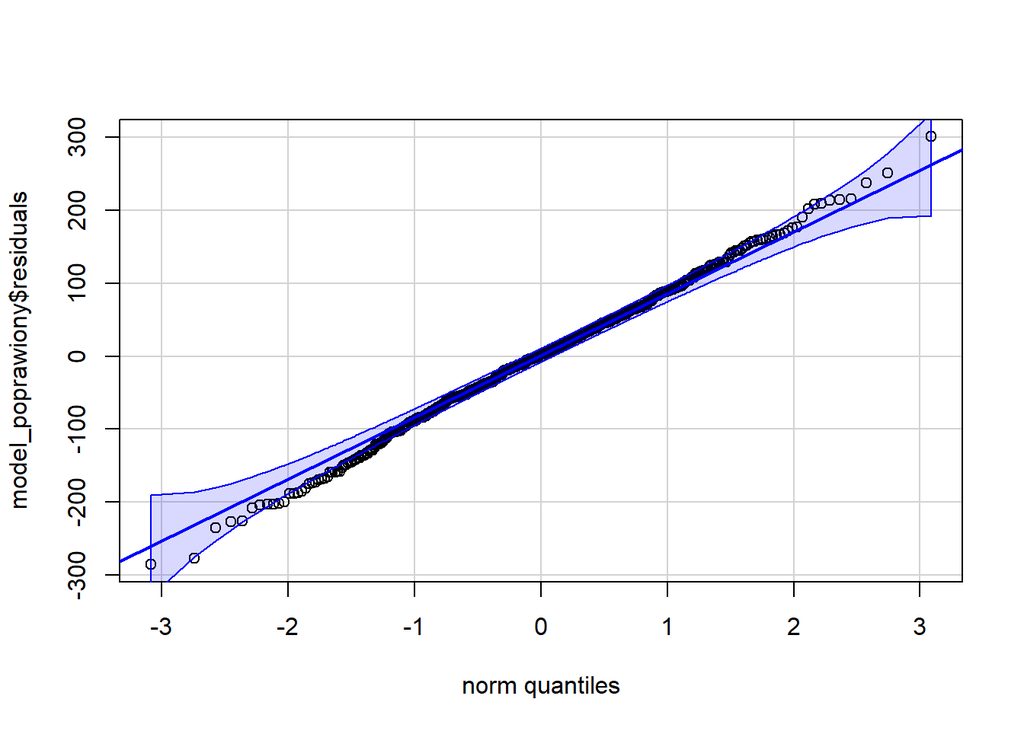

```r
qqPlot(model_poprawiony$residuals,id=FALSE)
```

**Założenie o normalności jest teraz spełnione, test Shapo-Wilka i qqPlot sugerują zgodność z rozkładem normalnym.**

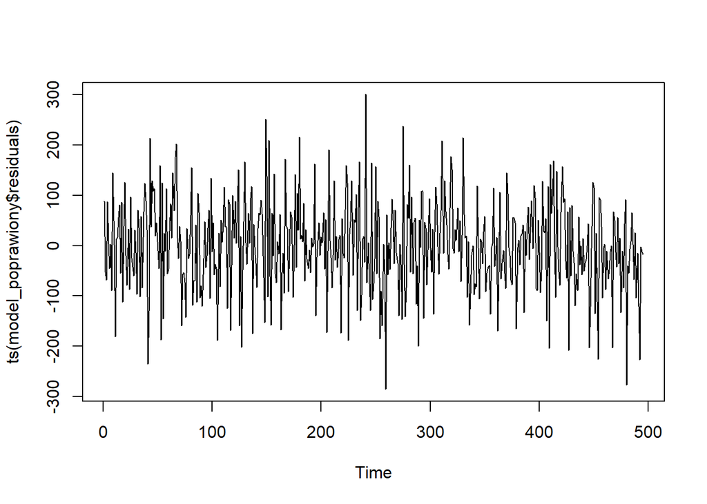

```r
plot(ts(model_poprawiony$residuals))
```

**Amplitudy nie grupują się w lejek, wykres oscyluje wokół zera.**

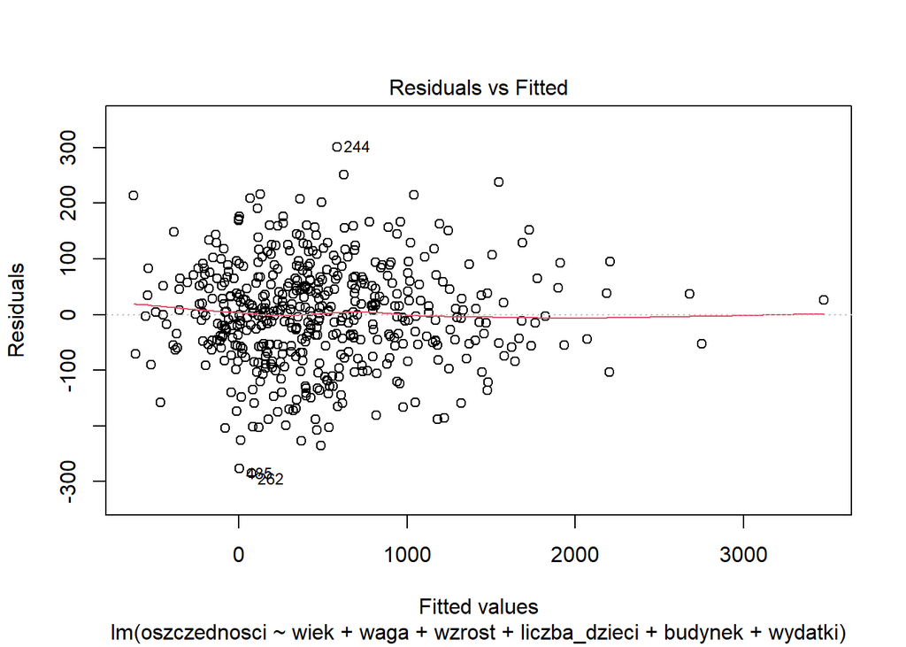

```r
plot(model_poprawiony, which = 1)
```

**Wydaje mi się, że na podstawie wykresu reszt założenie o homoskedatyczności nie jest spełnione, ale chyba nie do końca rozumiem na czym ono polega, więc ciężko jest mi stwierdzić. Końcowy model wydaje się mieć świetne dopasowanie, jednak wstrzymam się z oceną, jako że nie dzieliłem danych na treningowe i testowe. Dodatkowo dane do zadania są dość dziwne (mają mocne wady, mała np różnica między płciami we wzroście). Wydaje mi się, że model cechuje się sporym overfittingiem.**